# How we spend time on Youtube

Pang Qihan

## What is the purpose of the data

Have you being interested the main reason you waste (OF COURSE NOT) spend time on YouTube? We do!

[figure not shown]

The data explores how me and my friends (anonymous) spend time on YouTube by collecting our information during the latest use of YouTube every time and we put all these information into Google sheet. Overall, we have collected 43 submissions and used some of them for the plots

## Firstly, lets see ‘When’ and ‘How’

We firstly checked when in a day we have spend most time and we measure the time spend with increasing period of 30 mins each

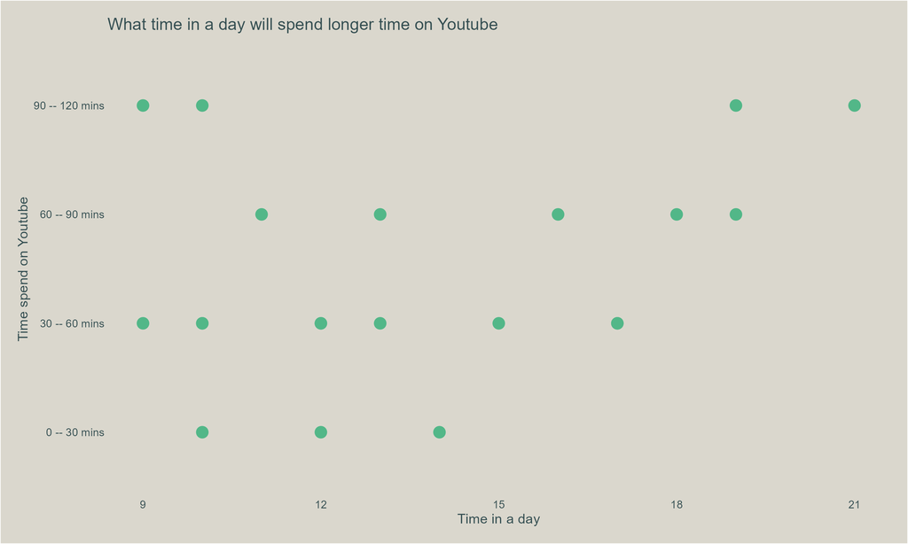

From the data, we can see that we often spend longer time on the night of a day. Clearly as a university student, we are more often studying or doing homework during daytime and enjoy some entertainment at night

There are also a few times during daytime with very large time spend and this is because sometimes we forget to submit our use on previous night or this data was collected on a weekends **(Definitely not marking around during workdays!)**

## Now lets check ‘Why’

Then, we are interested why we watch YouTube by looking the sections(category) of YouTube videos we watch most often.

Clearly, we are all gamers and full of sense of humour as we most often watch these two sections and it is very disappointing that only **one times** someone have watched videos about learning

[figure not shown]

If we link to the previous information, these videos are often watched during weekends and night-time for us to relax after a day of studies.

## Lastly, lets take a look about ‘How’ and ‘Whether’

Lastly, we decide to check for those times we watch not less than 10 videos, how many times we did for each number of videos we watched and whether we have watched someone we subscribed

It is interesting that we have a bimodal shape tells that we often watch videos between 10 and 14 videos or between 16 and 18 videos

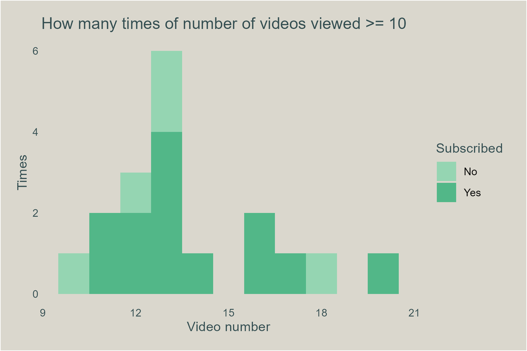

Also, it is noticed that most times for watching not less than than 10 videos, we’ve watched someone we subscribed. Based on previous information, we can believe that these videos should be games or humours videos created by someone we’ve subscribed and often watch.

## To conclude

Overall, we do spend a lot of time on YouTube for entertainment instead of studying (sad to notice)

[figure not shown]

This is clearly shown as we most often watch games or humour videos while we’ve also subscribed them and we watch longer time during night-time so luckily, this didn’t affect our studies during daytime (For now)